# Covid Image Analysis

In this notebook, we will be exploring images of lungs to determine the presence of the covid virus. The impact of Covid 19/Sars as a world wide pandemic has changes many lives from young to old. Using images of patient's lungs, the purpose of this notebook is to examine and identify the presence of covid. We will be training ML models and comparing the results. The image set will have both data of infected and non infected lungs. We will be dividing the sections of the notebook into EDA, Model Building, Improvements, Comparisons.

The data was retreived from Kaggle: SARS-COV-2 Ct-Scan Dataset

https://www.kaggle.com/datasets/plameneduardo/sarscov2-ctscan-dataset?select=COVID

### Importing Libraries

```python
#Importing necessary libraries
import os
import pandas as pd
import matplotlib.pyplot as plt
import math
import cv2
import numpy as np
import seaborn as sns
from sklearn.model_selection import train_test_split
from sklearn.cluster import KMeans
import itertools
from sklearn.metrics import accuracy_score
from sklearn.cluster import AgglomerativeClustering
from scipy.stats import zscore
from scipy.cluster.hierarchy import cophenet, dendrogram, linkage
from scipy.spatial.distance import pdist
from sklearn.model_selection import GridSearchCV
import warnings
warnings.filterwarnings('ignore')
from sklearn.metrics import make_scorer, silhouette_score
from sklearn.metrics import confusion_matrix
from sklearn.preprocessing import LabelBinarizer
# Tensorflow modules
import tensorflow as tf
from tensorflow.keras.preprocessing.image import ImageDataGenerator
from tensorflow.keras.models import Sequential
from tensorflow.keras.layers import Dense,Dropout,Flatten,Conv2D,MaxPooling2D,BatchNormalization
from tensorflow.keras.optimizers import Adam,SGD
```

### Reading the Data

Download the data from the kaggle website posted in the introduction of the notebook. The data comes in two folders with Covid images and Non-Covid Images. We will import from both paths and label them accordingly.

```python
#Local Paths to data
covid_train_path = "COVID"
non_covid_train_path = "non-COVID"

covid_train_path = os.path.join(covid_train_path)
non_covid_train_path = os.path.join(non_covid_train_path)
```

```python
#Loop through both folders and append the path and file names into a list
#We append filename, and a boolean indicating whether the image is covid (1) or non-covid (0)
covid_train_list = []
for file in os.listdir(covid_train_path):
    covid_train_list.append([covid_train_path + '/' + file, 1])

for file in os.listdir(non_covid_train_path):
    covid_train_list.append([non_covid_train_path + '/' + file, 0])
```

```python
#Create a Dataframe from the list created
covid_df = pd.DataFrame(covid_train_list, columns=['File', 'IsCovid'])
```

### Understanding the Data

We will do a brief view of the data. We will also process the data so that it is randomized.

```python
#First 5 elements of the df
covid_df.head()
```

|  | File | IsCovid |
| --- | --- | --- |
| 0 | COVID/Covid (1).png | 1 |
| 1 | COVID/Covid (10).png | 1 |
| 2 | COVID/Covid (100).png | 1 |
| 3 | COVID/Covid (1000).png | 1 |
| 4 | COVID/Covid (1001).png | 1 |

```python
#Randomizes the df such that covids and non-covids are mixed
covid_df = covid_df.sample(frac=1, random_state=1)
covid_df.index = np.arange(len(covid_df))
```

```python
#Review the data once more
covid_df.head()
```

|  | File | IsCovid |
| --- | --- | --- |
| 0 | non-COVID/Non-Covid (525).png | 0 |
| 1 | COVID/Covid (802).png | 1 |
| 2 | non-COVID/Non-Covid (1049).png | 0 |
| 3 | non-COVID/Non-Covid (27).png | 0 |
| 4 | non-COVID/Non-Covid (125).png | 0 |

### Exploratory Data Analysis

In this section, we will be visualizing the data even further and analyze any trends from the data.

```python
#Get a list of Filenames and list of labels
covid_list = covid_df['File'].tolist()
label_list = covid_df['IsCovid'].tolist()
```

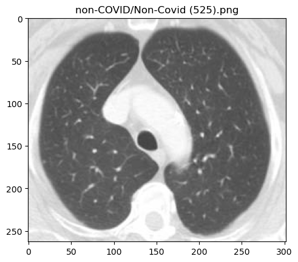

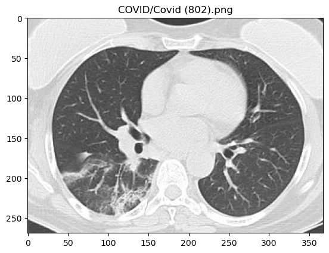

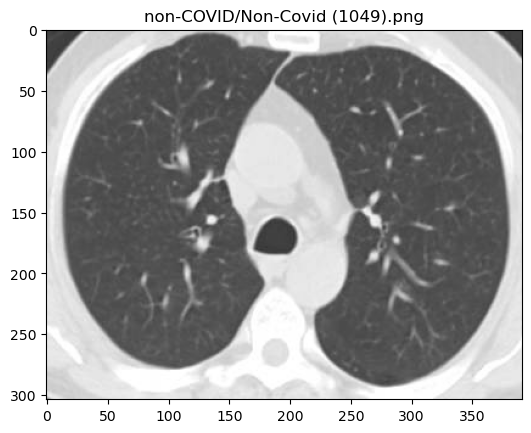

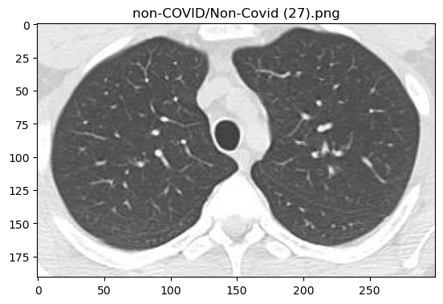

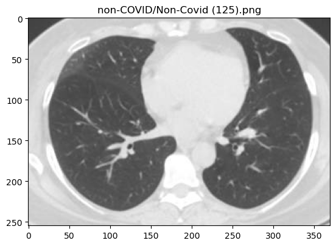

```python
#cv2.imread reads image file and converts into mxnxo size matrix
# where m is height, n is width, and o is the 3 values for rgb (or bgr)
for i in range(5):
    plt.imshow(cv2.imread(covid_list[i]))
    plt.title(covid_list[i])
    plt.show()
```

Next we can see the the count plot for each label.

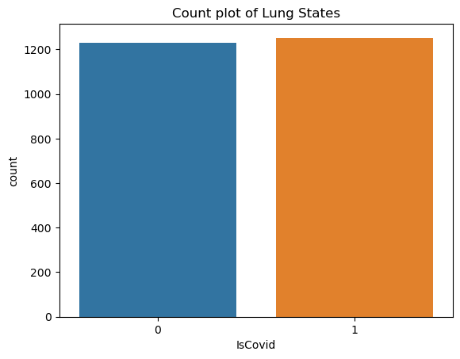

```python
#create a countplot for each Label
sns.countplot(x=covid_df['IsCovid'])
plt.title("Count plot of Lung States")
plt.show()
```

### Data Processing

Before proceeding into model building, we have to store the actual data, not the filename into some working data set. We have to examine the images data for size.

```python
#identify the shape of the images forthe first 10.
for i in range(10):
    print("Dimension of Image: " + str(covid_list[i]))
    print(cv2.imread(covid_list[i]).shape)
```

```
Dimension of Image: non-COVID/Non-Covid (525).png
(263, 302, 3)
Dimension of Image: COVID/Covid (802).png
(269, 368, 3)
Dimension of Image: non-COVID/Non-Covid (1049).png
(304, 391, 3)
Dimension of Image: non-COVID/Non-Covid (27).png
(191, 300, 3)
Dimension of Image: non-COVID/Non-Covid (125).png
(255, 370, 3)
Dimension of Image: COVID/Covid (1181).png
(252, 348, 3)
Dimension of Image: non-COVID/Non-Covid (929).png
(280, 377, 3)
Dimension of Image: non-COVID/Non-Covid (1050).png
(324, 391, 3)
Dimension of Image: COVID/Covid (337).png
(234, 339, 3)
Dimension of Image: COVID/Covid (1203).png
(250, 390, 3)
```

There are three dimensions of these images. M x n x o, where m is height, n is width o is the rgb (or bgr) values. We can see here that the heights and widths of each images differ. We need to process the image such that the shapes are uniform.

```python
#append our covid data list with the resized images
covid_data_list = []
for i in range(len(covid_list)):
    covid_data_list.append(cv2.resize(cv2.imread(covid_list[i]), (128,128)))
```

Let's recheck the size and revisit the image displays

```python
#Rechecking the sizes of each images
for i in range(10):
    print("Dimension of Image: " + str(covid_list[i]))
    print(covid_data_list[i].shape)
```

```
Dimension of Image: non-COVID/Non-Covid (525).png
(128, 128, 3)
Dimension of Image: COVID/Covid (802).png
(128, 128, 3)
Dimension of Image: non-COVID/Non-Covid (1049).png
(128, 128, 3)
Dimension of Image: non-COVID/Non-Covid (27).png
(128, 128, 3)
Dimension of Image: non-COVID/Non-Covid (125).png
(128, 128, 3)
Dimension of Image: COVID/Covid (1181).png
(128, 128, 3)
Dimension of Image: non-COVID/Non-Covid (929).png
(128, 128, 3)
Dimension of Image: non-COVID/Non-Covid (1050).png
(128, 128, 3)
Dimension of Image: COVID/Covid (337).png
(128, 128, 3)
Dimension of Image: COVID/Covid (1203).png
(128, 128, 3)
```

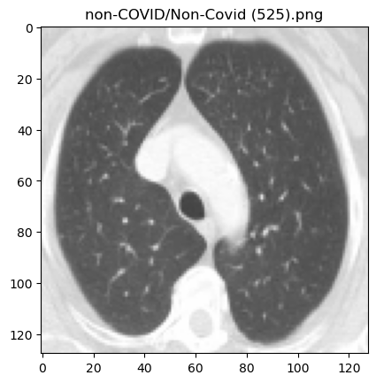

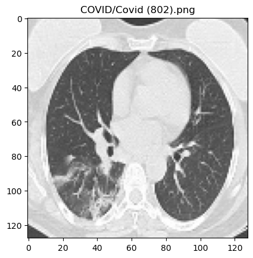

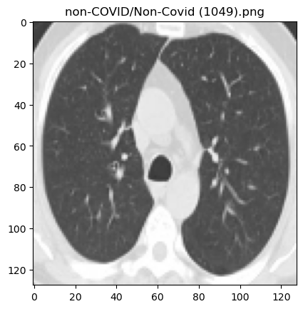

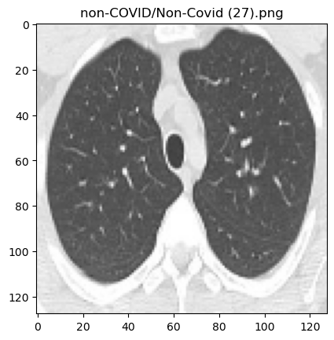

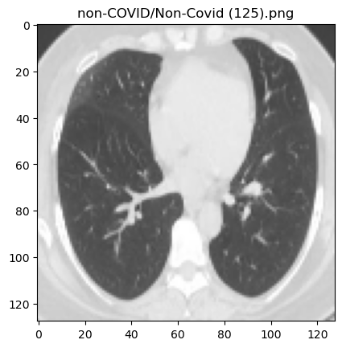

```python
#cv2.imread reads image file and converts into mxnxo size matrix
# where m is height, n is width, and o is the 3 values for rgb (or bgr)
for i in range(5):
    plt.imshow(covid_data_list[i])
    plt.title(covid_list[i])
    plt.show()
```

### Data Processing pt2

We'll continue with the data processing. First we need to convert the image colors from bgr to rgb. After splitting the data, we can normalize the numbers to a 0 to 1 range. The RGB dimension holds a value from 0 to 255 (8 bit number). Calculating with such high number can lead to increase in variable memory and overall slower performance. Finally, we will flatten out each image data into a one dimension array. The images are currently 128 x 128 x 3, and will be flatten to a single dimension array of length 49152.

```python
#Converting BGR to RGB
for i in range(len(covid_data_list)):
    cv2.cvtColor(covid_data_list[i], cv2.COLOR_BGR2RGB )
```

```python
X_train, X_test, y_train, y_test = train_test_split(np.array(covid_data_list), label_list, test_size=0.2)
```

```python
#Change the type to a value between 0 to 1
X_train = X_train.astype('float32')
X_test = X_test.astype('float32')
#normalization
X_train = X_train/255.0
X_test = X_test/255.0
```

```python
#Current Shape of the list of images
print("Shape of a single image:")
print(X_train[0].shape)
```

```
Shape of a single image:
(128, 128, 3)
```

```python
#Will need to save a training and testing set for ANN model
X_train_ann = X_train
X_test_ann = X_test
```

```python
X_train = X_train.reshape(len(X_train),-1)
X_test = X_test.reshape(len(X_test),-1)
```

```python
#Current Shape of the list of images
print("Shape of a single image:")
print(X_train[0].shape)
```

```
Shape of a single image:
(49152,)
```

### Model Building : K-means

First model we will use will be the k-means model. The data will have 2 clusters, which will indicate whether the data is Covid, or is Non-Covid.

```python
#Using SKlearn K-means clustering
kmeans = KMeans(n_clusters=2, n_init="auto").fit(X_train)
```

```python
#printing out labels (outputs)
print(kmeans.labels_[0:10])
```

```
[0 0 0 0 0 0 1 0 0 0]
```

```python
#printing out labels (outputs)
print(y_train[0:10])
```

```
[0, 1, 0, 1, 0, 0, 1, 1, 1, 0]
```

Now that we have the predicted values, we have to match the labels. Kmeans only categorizes the groups but does not distinguist the groups from the initial ones.

```python
#This function
def label_permute_compare(pred, actual ,n=5):
    """
    ytdf: labels dataframe object
    yp: clustering label prediction output
    Returns permuted label order and accuracy.
    Example output: (3, 4, 1, 2, 0), 0.74
    """
    label_set = set(actual)
    permutations = itertools.permutations(label_set)
    best_order = None
    best_accuracy = 0.0
    for order in permutations:
        predicted_labels = []
        for x in pred:
            predicted_labels.append(order[x])
        accuracy = accuracy_score(actual, predicted_labels)
        if accuracy > best_accuracy:
            best_accuracy = accuracy
            best_order = order

    return best_order, best_accuracy
```

```python
#Finding best accuracy and order
labelorder, acc = label_permute_compare(kmeans.labels_, y_train, 2)
print("Best Accuracy : " + str(acc))
print("Best Order : " + str(labelorder))
```

```
Best Accuracy : 0.6335685483870968
Best Order : (0, 1)
```

```python
predicted_labels = []
for x in kmeans.labels_:
    predicted_labels.append(labelorder[x])
#Calculating confusion matrix
print("Confusion Matrix : ")
print(confusion_matrix(predicted_labels, y_train))
```

```
Confusion Matrix :
[[815 567]
 [160 442]]
```

### Model Building : Agglomerative Clustering

Now let's use Agglomerative Clustering. This kind of clustering can use different sized non-spherical clusters. It also builds a heirarchy of clusters which might not be worth in this case where there are only two labels.

```python
#Building Agglomerative Clustering Model
AClust = AgglomerativeClustering(n_clusters=2, affinity='euclidean',  linkage='ward')
AClust.fit(X_train)
```

```
AgglomerativeClustering(affinity='euclidean')
```

```python
#printing out labels (outputs)
print(AClust.labels_[0:10])
```

```
[0 0 0 0 0 0 0 0 0 0]
```

```python
#printing out labels (outputs)
print(y_train[0:10])
```

```
[0, 1, 0, 1, 0, 0, 1, 1, 1, 0]
```

```python
#Finding best accuracy and order
labelorder, acc = label_permute_compare(AClust.labels_, y_train, 2)
print("Best Accuracy : " + str(acc))
print("Best Order : " + str(labelorder))
```

```
Best Accuracy : 0.594758064516129
Best Order : (0, 1)
```

```python
predicted_labels = []
for x in AClust.labels_:
    predicted_labels.append(labelorder[x])
#Calculating confusion matrix
print("Confusion Matrix : ")
print(confusion_matrix(predicted_labels, y_train))
```

```
Confusion Matrix :
[[921 750]
 [ 54 259]]
```

Drawing the dendrogram

```python
#Creating the linkages for Dendrogram
Z = linkage(X_train, metric='euclidean', method='ward')


#Finding cophenet coefficient
c, coph_dists = cophenet(Z , pdist(X_train))

print('Cophenet Coefficient : ' + str(c))
```

```
Cophenet Coefficient : 0.5397277003015745
```

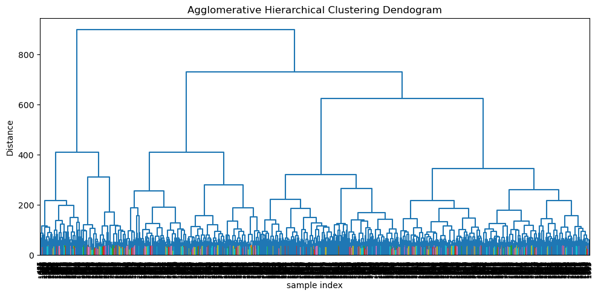

```python
plt.figure(figsize=(10, 5))
plt.title('Agglomerative Hierarchical Clustering Dendogram')
plt.xlabel('sample index')
plt.ylabel('Distance')
dendrogram(Z, leaf_rotation=90.,color_threshold = 40, leaf_font_size=8. )
plt.tight_layout()
```

### Hyper Parameter Tuning: Agglomerative Clustering

Let's do some hyper parameter tuning for our Agglomerative Clustering. We will change the linkage and affinity to see the best fit model.

```python
#New Agglomerative model
AClust_model = AgglomerativeClustering()

#Param Grids
param_grid = {
    'n_clusters': [2],
    'metric': ['euclidean', 'manhattan', 'cosine'],
    'linkage':['ward', 'complete', 'average', 'single']
}
#Declare a silhouette scorer for Clustering
silhouette_scorer = make_scorer(silhouette_score)
```

```python
#GridSearchCV model
grid_search = GridSearchCV(AClust_model, param_grid=param_grid, cv=5,scoring=silhouette_scorer)
grid_search.fit(X_train)
```

```
GridSearchCV(cv=5, estimator=AgglomerativeClustering(),
             param_grid={'linkage': ['ward', 'complete', 'average', 'single'],
                         'metric': ['euclidean', 'manhattan', 'cosine'],
                         'n_clusters': [2]},
             scoring=make_scorer(silhouette_score))
```

Well that took a while, we will see the best scores for this grid search

```python
# Print the best parameters and the corresponding performance score
print("Best Parameters: ", grid_search.best_params_)
```

```
Best Parameters:  {'linkage': 'ward', 'metric': 'euclidean', 'n_clusters': 2}
```

It seems like our initial hyper parameters gave the best results for silhouette score.

### Model Building : Neural Networks

We will be comparing the unsupervised learning models with supervised learning models. We will be using neural networks (artificial neural network and convolutional neural network) to detect covid images.

We will need to encode the labels into two different columns which represent the last two nodes in the last layer of the neural network.

```python
#Encoding
label_enc = []
label_test_enc = []
for i in range(len(y_train)):
    if (y_train[i] == 1):
        label_enc.append([0,1])
    else:
        label_enc.append([1,0])
for i in range(len(y_test)):
    if (y_test[i] == 1):
        label_test_enc.append([0,1])
    else:
        label_test_enc.append([1,0])
label_enc = np.array(label_enc)
label_test_enc = np.array(label_test_enc)
```

```python
print(label_enc[0:5])
```

[output not shown]

**ANN Model**

```python
#Using ANN Model
ann_model = Sequential()
ann_model.add(Flatten(input_shape=(128, 128,3)))
ann_model.add(Dense(100, activation='relu'))
ann_model.add(Dense(2, activation='sigmoid'))
opt = SGD(learning_rate=0.01, momentum=0.9)
ann_model.compile(optimizer=opt,
              loss='categorical_crossentropy',
              metrics=['accuracy'])
ann_model.summary()
```

```
Model: "sequential_4"
_________________________________________________________________
 Layer (type)                Output Shape              Param #
=================================================================
 flatten_4 (Flatten)         (None, 49152)             0

 dense_8 (Dense)             (None, 100)               4915300

 dense_9 (Dense)             (None, 2)                 202

=================================================================
Total params: 4915502 (18.75 MB)
Trainable params: 4915502 (18.75 MB)
Non-trainable params: 0 (0.00 Byte)
_________________________________________________________________
```

```python
#Fitting model with data
history_ann = ann_model.fit(X_train_ann,label_enc,
                                       batch_size=128,
                                       shuffle=False,
                                       epochs=15,
                                       steps_per_epoch=X_train_ann.shape[0] // 128,
                                       verbose=1)
```

The ann model accuracy after 15 epochs is 0.5216.

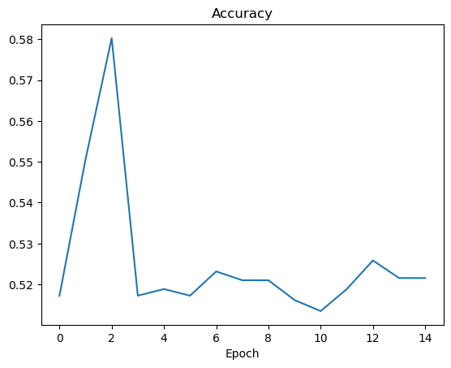

```python
#plot of cnn epochs
plt.plot(history_ann.history['accuracy'])
plt.title('Accuracy')
plt.xlabel('Epoch')
plt.show()
```

```python
#predicting
y_pred=ann_model.predict(X_test_ann)
```

```python
#accuracy score
y_pred_flattened = []
for i in range(len(y_pred)):
    if(y_pred[i][0 ] < 5):
        y_pred_flattened.append(0)
    else:
        y_pred_flattened.append(1)
print(y_pred_flattened[0:10])
```

```
[0, 0, 0, 0, 0, 0, 0, 0, 0, 0]
```

```python
accuracy = accuracy_score(y_pred_flattened, y_test)
print("Test Data Accuracy : " + str(accuracy))
```

```
Test Data Accuracy : 0.5533199195171026
```

**CNN Model**

```python
#Buiding CNN Model
cnn_model = Sequential()
cnn_model.add(Conv2D(128, (3,3), activation='relu', input_shape=(128, 128, 3), padding = 'same'))
cnn_model.add(MaxPooling2D(2,2))
cnn_model.add(BatchNormalization())
cnn_model.add(Conv2D(32, (3,3), activation='relu', padding = 'same'))
cnn_model.add(MaxPooling2D(2,2))
cnn_model.add(BatchNormalization())
cnn_model.add(Conv2D(32, (3,3), activation='relu', padding = 'same'))
cnn_model.add(MaxPooling2D(2,2))
cnn_model.add(Conv2D(16, (3,3), activation='relu', padding = 'same'))
cnn_model.add(Flatten())
cnn_model.add(Dense(128, activation='relu'))
cnn_model.add(Dropout(0.25))
cnn_model.add(Dense(32, activation='relu'))
cnn_model.add(Dense(2, activation='sigmoid'))
```

```python
cnn_model.compile(loss="binary_crossentropy", optimizer="adam", metrics = ['accuracy'])
cnn_model.summary()
```

```
Model: "sequential_8"
_________________________________________________________________
 Layer (type)                Output Shape              Param #
=================================================================
 conv2d_12 (Conv2D)          (None, 128, 128, 128)     3584

 max_pooling2d_9 (MaxPoolin  (None, 64, 64, 128)       0
 g2D)

 batch_normalization_6 (Bat  (None, 64, 64, 128)       512
 chNormalization)

 conv2d_13 (Conv2D)          (None, 64, 64, 32)        36896

 max_pooling2d_10 (MaxPooli  (None, 32, 32, 32)        0
 ng2D)

 batch_normalization_7 (Bat  (None, 32, 32, 32)        128
 chNormalization)

 conv2d_14 (Conv2D)          (None, 32, 32, 32)        9248

 max_pooling2d_11 (MaxPooli  (None, 16, 16, 32)        0
 ng2D)

 conv2d_15 (Conv2D)          (None, 16, 16, 16)        4624

 flatten_8 (Flatten)         (None, 4096)              0

 dense_19 (Dense)            (None, 128)               524416

 dropout_3 (Dropout)         (None, 128)               0

 dense_20 (Dense)            (None, 32)                4128

 dense_21 (Dense)            (None, 2)                 66

=================================================================
Total params: 583602 (2.23 MB)
Trainable params: 583282 (2.23 MB)
Non-trainable params: 320 (1.25 KB)
_________________________________________________________________
```

```python
#Fitting model with data
history_cnn = cnn_model.fit(X_train_ann,label_enc,
                                       batch_size=128,
                                       shuffle=False,
                                       epochs=15,
                                       steps_per_epoch=X_train_ann.shape[0] // 128,
                                       verbose=1)
```

The cnn model accuracy after 15 epochs is 0.9774.

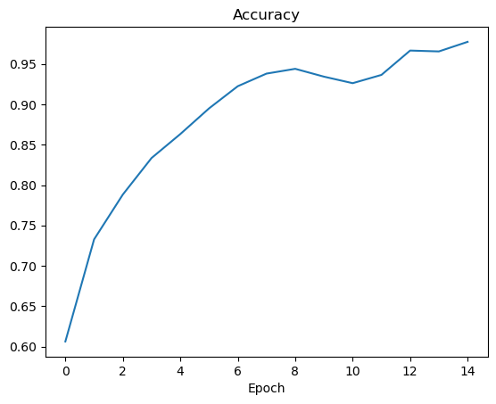

```python
#plot of cnn epochs
plt.plot(history_cnn.history['accuracy'])
plt.title('Accuracy')
plt.xlabel('Epoch')
plt.show()
```

### Conclusion

K-means: 0.633 accuracy

Agglomerate: 0.594 accuracy

ANN: 0.5216 accuracy

In conclusion, after trying out four different machine learning tools – KMeans, agglomerative clustering, artificial neural network, and convolutional neural network – it turns out the convolutional neural network is the top performer. The first two are good at finding patterns in data, while the artificial neural network can handle complex relationships. However, when it comes to dealing with images, the convolutional neural network really shines. It's the go-to choice for tasks like recognizing and sorting images because it's excellent at understanding the details in complex data.